# DATASCI 506 HW 4

Author

Yiwen Hua

Answers are on Github at https://github.com/Yiwen-Hua/STATS-506-HW-4.git

## Problem 1

```r
library(tidyverse)
nzge <- read_rds("nzge.rds") |> as_tibble()

glimpse(nzge)
```

```
Rows: 728,602
Columns: 9
$ approx_location   <chr> "Albury", "Arowhenua", "Burke Pass", "Cannington", "…
$ voting_place      <chr> "School", "Maori School, Huirapa Street", "Alpine Ca…
$ party             <chr> "ACT New Zealand", "ACT New Zealand", "ACT New Zeala…
$ votes             <dbl> 16, 4, 13, 6, 1, 16, 6, 17, 48, 14, 32, 47, 8, 7, 11…
$ electorate        <chr> "Aoraki", "Aoraki", "Aoraki", "Aoraki", "Aoraki", "A…
$ voting_type       <chr> "Party", "Party", "Party", "Party", "Party", "Party"…
$ candidate         <chr> NA, NA, NA, NA, NA, NA, NA, NA, NA, NA, NA, NA, NA, …
$ election_year     <dbl> 2002, 2002, 2002, 2002, 2002, 2002, 2002, 2002, 2002…
$ electorate_number <dbl> 1, 1, 1, 1, 1, 1, 1, 1, 1, 1, 1, 1, 1, 1, 1, 1, 1, 1…
```

```r
nzge |> distinct(election_year, voting_type)
```

```
# A tibble: 10 × 2
   election_year voting_type
           <dbl> <chr>
 1          2002 Party
 2          2002 Candidate
 3          2005 Party
 4          2005 Candidate
 5          2008 Party
 6          2008 Candidate
 7          2011 Party
 8          2011 Candidate
 9          2014 Party
10          2014 Candidate
```

### (a)

```r
vote_totals <- nzge |>
  group_by(election_year, voting_type) |>
  summarize(total_votes = sum(votes, na.rm = TRUE), .groups = "drop") |>
  arrange(desc(total_votes))

print(vote_totals, n = Inf)
```

```
# A tibble: 10 × 3
   election_year voting_type total_votes
           <dbl> <chr>             <dbl>
 1          2014 Party           2416479
 2          2014 Candidate       2375493
 3          2008 Party           2356536
 4          2008 Candidate       2325598
 5          2005 Party           2286190
 6          2005 Candidate       2260670
 7          2011 Party           2257336
 8          2011 Candidate       2225766
 9          2002 Party           2040248
10          2002 Candidate       2022115
```

### (b)

```r
# Keep valid votes for the party comparisons
valid_votes <- nzge |>
  filter(!is.na(party), party != "",
         !str_detect(party, regex("^Informal", ignore_case = TRUE)))

candidate_shares_2014 <- valid_votes |>
  filter(election_year == 2014, voting_type == "Candidate") |>
  group_by(party) |>
  summarize(total_votes = sum(votes, na.rm = TRUE), .groups = "drop") |>
  mutate(percent = 100 * total_votes / sum(total_votes)) |>
  arrange(desc(percent))

candidate_shares_2014 |>
  mutate(percent = round(percent, 2)) |>
  print(n = Inf)
```

```
# A tibble: 24 × 3
   party                            total_votes percent
   <chr>                                  <dbl>   <dbl>
 1 National Party                       1081787   46.1
 2 Labour Party                          801287   34.1
 3 Green Party                           165718    7.06
 4 Conservative Party                     81075    3.45
 5 New Zealand First Party                73384    3.13
 6 Maori Party                            42108    1.79
 7 MANA Movement                          32333    1.38
 8 ACT New Zealand                        27778    1.18
 9 United Future                          14722    0.63
10 Aotearoa Legalise Cannabis Party        4936    0.21
11 Internet Party                          4848    0.21
12 Democrats for Social Credit             4647    0.2
13 Ban1080                                 4448    0.19
14 Independent                             3864    0.16
15 NZ Independent Coalition                1929    0.08
16 Focus New Zealand                       1797    0.08
17 Money Free Party                         391    0.02
18 Communist League                         135    0.01
19 Climate Party                            116    0
20 Human Rights Party                        76    0
21 The Expats                                70    0
22 Alliance                                  59    0
23 NZ Economic Euthenics Party               51    0
24 Patriotic Revolutionary Front             48    0
```

### (c)

```r
vote_leaders <- valid_votes |>
  group_by(election_year, voting_type, party) |>
  summarize(total_votes = sum(votes, na.rm = TRUE), .groups = "drop") |>
  group_by(election_year, voting_type) |>
  slice_max(order_by = total_votes, n = 1, with_ties = TRUE) |>
  ungroup() |>
  arrange(election_year, voting_type)

print(vote_leaders, n = Inf)
```

```
# A tibble: 10 × 4
   election_year voting_type party          total_votes
           <dbl> <chr>       <chr>                <dbl>
 1          2002 Candidate   Labour Party        891866
 2          2002 Party       Labour Party        838219
 3          2005 Candidate   National Party      902874
 4          2005 Party       Labour Party        935319
 5          2008 Candidate   National Party     1072024
 6          2008 Party       National Party     1053398
 7          2011 Candidate   National Party     1027696
 8          2011 Party       National Party     1058636
 9          2014 Candidate   National Party     1081787
10          2014 Party       National Party     1131501
```

## Problem 2

### (a)

```r
atp <- read_csv("atp_matches_2019.csv", show_col_types = FALSE)

atp |>
  summarize(tournaments = n_distinct(tourney_id, na.rm = TRUE))
```

```
# A tibble: 1 × 1
  tournaments
        <int>
1         128
```

The 2019 ATP match dataset contained 128 distinct tournament IDs.

### (b)

```r
# Inspect tournament levels and round codes
atp |> count(tourney_level, round)
```

```
# A tibble: 25 × 3
   tourney_level round     n
   <chr>         <chr> <int>
 1 A             F        52
 2 A             QF      208
 3 A             R16     416
 4 A             R32     692
 5 A             R64      48
 6 A             RR        9
 7 A             SF      104
 8 D             RR      172
 9 F             F         2
10 F             RR       24
# ℹ 15 more rows
```

```r
# Count distinct finals won by each player
titles <- atp |>
  filter(round == "F", !is.na(winner_id)) |>
  group_by(winner_id) |>
  summarize(
    player = first(winner_name),
    titles = n_distinct(tourney_id, na.rm = TRUE),
    .groups = "drop"
  )

titles |>
  summarize(
    players_with_multiple_titles = sum(titles > 1),
    most_titles = max(titles)
  )
```

```
# A tibble: 1 × 2
  players_with_multiple_titles most_titles
                         <int>       <int>
1                           12           5
```

```r
titles |>
  slice_max(order_by = titles, n = 1, with_ties = TRUE) |>
  select(player, titles)
```

```
# A tibble: 2 × 2
  player         titles
  <chr>           <int>
1 Novak Djokovic      5
2 Dominic Thiem       5
```

Using recorded singles finals to identify tournament champions, 12 players won more than one tournament. Novak Djokovic and Dominic Thiem tied for the most titles, with five each.

### (c)

```r
ace_comparison <- atp |>
  drop_na(w_ace, l_ace) |>
  mutate(ace_diff = w_ace - l_ace) |>
  summarize(
    matches = n(),
    mean_diff = mean(ace_diff),
    median_diff = median(ace_diff),
    winner_more_pct = 100 * mean(ace_diff > 0),
    tied_pct = 100 * mean(ace_diff == 0),
    loser_more_pct = 100 * mean(ace_diff < 0)
  )

ace_comparison
```

```
# A tibble: 1 × 6
  matches mean_diff median_diff winner_more_pct tied_pct loser_more_pct
    <int>     <dbl>       <dbl>           <dbl>    <dbl>          <dbl>
1    2694      1.70           1            57.3     8.35           34.4
```

Among the 2,694 matches with ace counts for both players, winners hit more aces in 57.3% of matches, losers hit more in 34.4%, and the counts were equal in 8.35%. Winners averaged 1.70 more aces per match, suggesting that winners tended to hit more aces than losers in this dataset.

### (d)

```r
player_matches <- bind_rows(
  atp |> transmute(player_id = winner_id, player = winner_name, won = TRUE),
  atp |> transmute(player_id = loser_id, player = loser_name, won = FALSE)
)

top_win_rates <- player_matches |>
  filter(!is.na(player_id)) |>
  group_by(player_id) |>
  summarize(
    player = first(player),
    matches = n(),
    wins = sum(won),
    win_rate = mean(won),
    .groups = "drop"
  ) |>
  filter(matches >= 5) |>
  slice_max(win_rate, n = 1, with_ties = TRUE) |>
  mutate(win_rate = scales::percent(win_rate, accuracy = 0.1)) |>
  select(player, matches, wins, win_rate)

print(top_win_rates, n = Inf)
```

```
# A tibble: 1 × 4
  player       matches  wins win_rate
  <chr>          <int> <int> <chr>
1 Rafael Nadal      69    60 87.0%
```

Among players who played at least five matches, Rafael Nadal had the highest win rate: 87.0%, with 60 wins in 69 matches.

## Problem 3

```r
covid <- read_csv("us-states.csv", show_col_types = FALSE) |>
  mutate(date = as.Date(date))

us_cases <- covid |>
  filter(state %in% state.name, !is.na(cases_avg)) |>
  group_by(date) |>
  summarize(daily_avg = sum(cases_avg), .groups = "drop") |>
  arrange(date)

# Find peaks with a complete 35-day window on each side
window_days <- 35
days <- us_cases$date
cases <- us_cases$daily_avg

# Identify whether a date qualifies as a case peak.
# Inputs: row index i, ordered dates, daily case averages, and window half-width in days.
# Returns: one logical value indicating whether the date qualifies.
is_case_peak <- function(i, days, cases, window_days) {
  if (days[i] - window_days < min(days) ||
      days[i] + window_days > max(days)) {
    return(FALSE)
  }

  left <- which(days >= days[i] - window_days & days < days[i])
  right <- which(days > days[i] & days <= days[i] + window_days)
  window <- c(left, i, right)

  is_peak <- i == window[which.max(cases[window])]
  rise <- cases[i] - max(min(cases[left]), min(cases[right]))

  is_peak && cases[i] >= 25000 && rise >= 15000
}

peak_idx <- which(map_lgl(
  seq_along(days),
  is_case_peak,
  days = days,
  cases = cases,
  window_days = window_days
))

spikes <- us_cases |>
  slice(peak_idx) |>
  mutate(size = if_else(daily_avg >= 100000, "Major", "Minor"))

spikes |> count(size, name = "peaks")
```

```
# A tibble: 2 × 2
  size  peaks
  <chr> <int>
1 Major     4
2 Minor     3
```

```r
spikes |> select(date, size, daily_avg) |> print(n = Inf)
```

```
# A tibble: 7 × 3
  date       size  daily_avg
  <date>     <chr>     <dbl>
1 2020-07-19 Minor    66328.
2 2021-01-11 Major   250256.
3 2021-04-14 Minor    69937.
4 2021-09-02 Major   163358.
5 2022-01-14 Major   796116.
6 2022-07-15 Major   127556.
7 2022-12-23 Minor    68915.
```

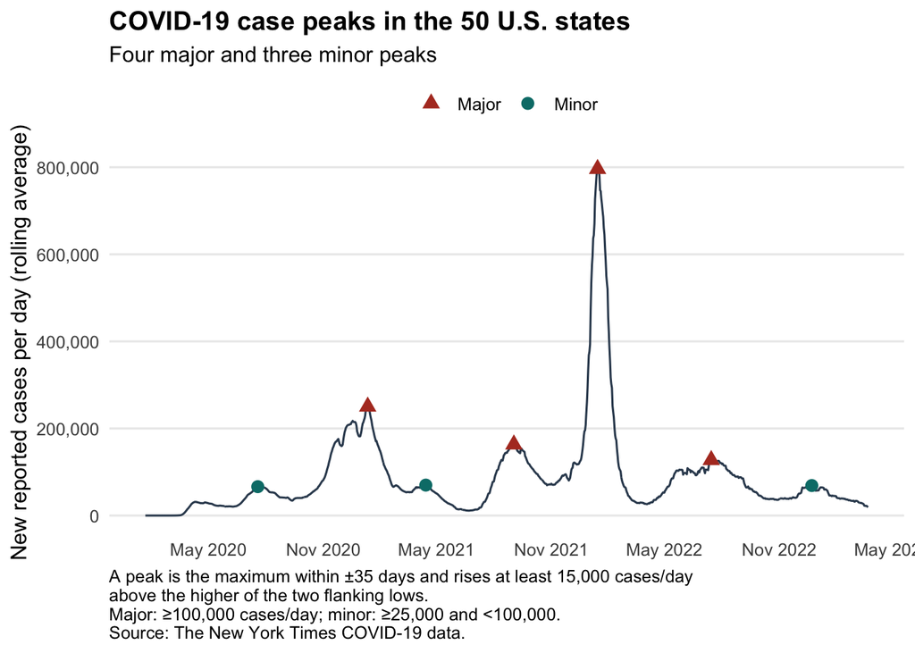

```r
ggplot(us_cases, aes(date, daily_avg)) +
  geom_line(color = "#34495E", linewidth = 0.55) +
  geom_point(
    data = spikes,
    aes(color = size, shape = size),
    size = 3
  ) +
  scale_color_manual(values = c(Major = "#B23A28", Minor = "#007C78")) +
  scale_shape_manual(values = c(Major = 17, Minor = 16)) +
  scale_x_date(date_breaks = "6 months", date_labels = "%b %Y") +
  scale_y_continuous(labels = scales::label_comma()) +
  labs(
    title = "COVID-19 case peaks in the 50 U.S. states",
    subtitle = "Four major and three minor peaks",
    x = NULL,
    y = "New reported cases per day (rolling average)",
    color = NULL,
    shape = NULL,
    caption = paste(
  "A peak is the maximum within ±35 days and rises at least 15,000 cases/day",
  "above the higher of the two flanking lows.",
  "Major: ≥100,000 cases/day; minor: ≥25,000 and <100,000.",
  "Source: The New York Times COVID-19 data.",
  sep = "\n"
)
  ) +
  theme_minimal(base_size = 12) +
  theme(
    legend.position = "top",
    panel.grid.minor = element_blank(),
    panel.grid.major.x = element_blank(),
    plot.title = element_text(face = "bold"),
    plot.caption = element_text(hjust = 0)
  )
```

Using the stated peak criteria, the 50-state series had four major and three minor peaks. The largest peak occurred on January 14, 2022, at approximately 796,116 reported cases per day. These counts depend on the chosen window and thresholds.

### (b)

```r
state_rates <- covid |>
  filter(state %in% state.name, !is.na(cases_avg_per_100k)) |>
  select(date, state, cases_avg_per_100k)

# Rank states using only dates with a rate for all 50 states
common_dates <- state_rates |>
  distinct(date, state) |>
  count(date, name = "states_reporting") |>
  filter(states_reporting == length(state.name))

state_ranking <- state_rates |>
  semi_join(common_dates, by = "date") |>
  group_by(state) |>
  summarize(
    overall_rate = mean(cases_avg_per_100k),
    .groups = "drop"
  ) |>
  arrange(desc(overall_rate))

extreme_states <- bind_rows(
  state_ranking |> slice_max(overall_rate, n = 1) |> mutate(rank = "Highest"),
  state_ranking |> slice_min(overall_rate, n = 1) |> mutate(rank = "Lowest")
)

common_dates |>
  summarize(start = min(date), end = max(date), dates_used = n())
```

```
# A tibble: 1 × 3
  start      end        dates_used
  <date>     <date>          <int>
1 2020-03-17 2023-03-23       1102
```

```r
extreme_states |> select(rank, state, overall_rate)
```

```
# A tibble: 2 × 3
  rank    state        overall_rate
  <chr>   <chr>               <dbl>
1 Highest Rhode Island         39.3
2 Lowest  Maine                20.0
```

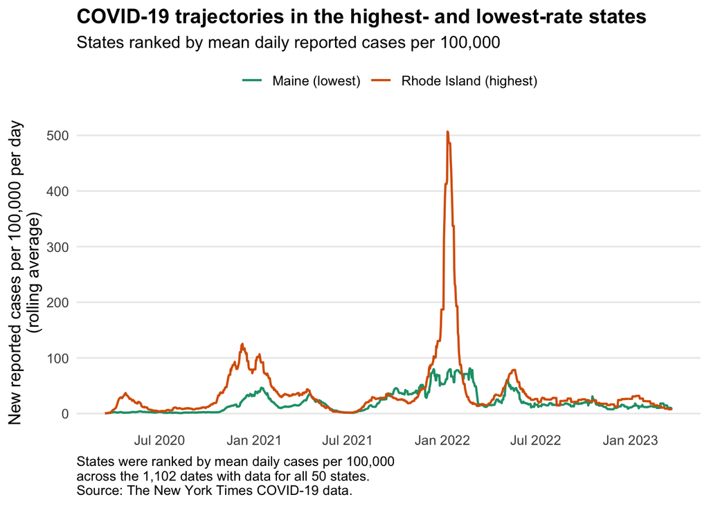

```r
extreme_series <- state_rates |>
  semi_join(common_dates, by = "date") |>
  inner_join(extreme_states, by = "state") |>
  mutate(series = paste0(state, " (", tolower(rank), ")"))

ggplot(extreme_series, aes(date, cases_avg_per_100k, color = series)) +
  geom_line(linewidth = 0.75) +
  scale_color_brewer(palette = "Dark2") +
  scale_x_date(date_breaks = "6 months", date_labels = "%b %Y") +
  scale_y_continuous(labels = scales::label_comma()) +
  labs(
    title = "COVID-19 trajectories in the highest- and lowest-rate states",
    subtitle = "States ranked by mean daily reported cases per 100,000",
    x = NULL,
    y = "New reported cases per 100,000 per day\n(rolling average)",
    color = NULL,
    caption = paste(
  "States were ranked by mean daily cases per 100,000",
  "across the 1,102 dates with data for all 50 states.",
  "Source: The New York Times COVID-19 data.",
  sep = "\n")
  ) +
  theme_minimal(base_size = 12) +
  theme(
    legend.position = "top",
    panel.grid.minor = element_blank(),
    panel.grid.major.x = element_blank(),
    plot.title = element_text(face = "bold"),
    plot.caption = element_text(hjust = 0)
  )
```

```r
extreme_series |>
  group_by(state) |>
  slice_max(cases_avg_per_100k, n = 1, with_ties = FALSE) |>
  ungroup() |>
  select(state, date, peak_rate = cases_avg_per_100k)
```

```
# A tibble: 2 × 3
  state        date       peak_rate
  <chr>        <date>         <dbl>
1 Maine        2022-02-23      81.2
2 Rhode Island 2022-01-11     507.
```

Across the 1,102 dates with data for all 50 states, Rhode Island had the highest mean daily reported case rate (39.3 per 100,000), and Maine had the lowest (20.0 per 100,000). Rhode Island peaked earlier and much higher, at about 507 per 100,000 on January 11, 2022, compared with Maine’s peak of 81.2 on February 23, 2022.

### (c)

```r
threshold <- 1
required_days <- 7

onsets <- state_rates |>
  group_by(state) |>
  arrange(date, .by_group = TRUE) |>
  mutate(
    above = cases_avg_per_100k >= threshold,
    new_run = above & (
      !lag(above, default = FALSE) |
        date != lag(date, default = first(date)) + 1
    ),
    run_id = cumsum(new_run)
  ) |>
  filter(above) |>
  group_by(state, run_id) |>
  summarize(onset = min(date), days_above = n(), .groups = "drop") |>
  filter(days_above >= required_days) |>
  group_by(state) |>
  summarize(onset = min(onset), .groups = "drop")

first_states <- onsets |>
  slice_min(onset, n = 5, with_ties = TRUE) |>
  arrange(onset, state)

first_states
```

```
# A tibble: 6 × 2
  state      onset
  <chr>      <date>
1 Washington 2020-03-15
2 New York   2020-03-18
3 Louisiana  2020-03-19
4 New Jersey 2020-03-19
5 Michigan   2020-03-21
6 Vermont    2020-03-21
```

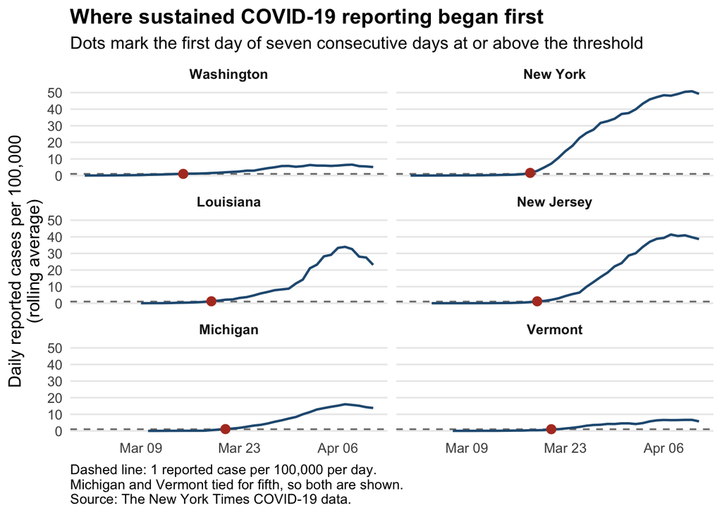

```r
early_series <- state_rates |>
  inner_join(first_states, by = "state") |>
  filter(
    date >= min(first_states$onset) - 14,
    date <= max(first_states$onset) + 21
  ) |>
  mutate(state = factor(state, levels = first_states$state))

onset_points <- early_series |>
  filter(date == onset)

ggplot(early_series, aes(date, cases_avg_per_100k)) +
  geom_hline(
    yintercept = threshold,
    linetype = "dashed",
    color = "#777777"
  ) +
  geom_line(color = "#245A81", linewidth = 0.8) +
  geom_point(data = onset_points, color = "#B23A28", size = 2.6) +
  facet_wrap(vars(state), ncol = 2) +
  scale_x_date(date_breaks = "2 weeks", date_labels = "%b %d") +
  labs(
    title = "Where sustained COVID-19 reporting began first",
    subtitle = "Dots mark the first day of seven consecutive days at or above the threshold",
    x = NULL,
    y = "Daily reported cases per 100,000\n(rolling average)",
    caption = paste(
  "Dashed line: 1 reported case per 100,000 per day.",
  "Michigan and Vermont tied for fifth, so both are shown.",
  "Source: The New York Times COVID-19 data.",
  sep = "\n"
)
)+
  theme_minimal(base_size = 12) +
  theme(
    panel.grid.minor = element_blank(),
    panel.grid.major.x = element_blank(),
    strip.text = element_text(face = "bold"),
    plot.title = element_text(face = "bold"),
    plot.caption = element_text(hjust = 0)
  )
```

Using the first day of seven consecutive days with at least one reported case per 100,000 per day as the onset, Washington qualified first on March 15, 2020, followed by New York on March 18 and Louisiana and New Jersey on March 19. Michigan and Vermont tied for fifth on March 21, so both are shown. These dates reflect sustained reported case rates rather than the first infections.